```python
%%html
<link href='https://fonts.googleapis.com/css?family=Roboto' rel='stylesheet'>
<style>
body {
    font-family: 'Roboto', 'Helvetica', sans-serif;
    font-size: 12px;
}
</style>
```

# **An Analysis of the Presence of Asian Musicians in Global Top Music Charts**

```python
import pandas as pd
import numpy as np
import matplotlib.pyplot as plt
import matplotlib.patches as mpatches
import altair as alt
import seaborn as sns
import re
import os
import json
import sqlite3
import requests
from datetime import datetime, timedelta
from bs4 import BeautifulSoup
from numpy.testing import assert_equal
from pywaffle import Waffle

import plotly.graph_objects as go
from plotly.subplots import make_subplots


from PIL import Image

from IPython.display import HTML, display
import pprint

import warnings
warnings.filterwarnings('ignore')
```

```python
# Create toggle cell button
font = "Roboto-Regular.ttf"
pp = pprint.PrettyPrinter(indent=4, width=100)


HTML('''
<style>
.output_png {
    display: table-cell;
    text-align: center;
    vertical-align: middle;
}

.output {
    display: flex;
    align-items: left;
    text-align: justify;
}

</style>


<script>
code_show=true;
function code_toggle() {
 if (code_show){
 $('div.input').hide();
 } else {
 $('div.input').show();
 }
 code_show = !code_show
}
$( document ).ready(code_toggle);
</script>
<form action="javascript:code_toggle()"><input type="submit"
value="Click here to toggle on/off the raw code."></form>
''')
```

# Executive Summary

Asians in the western world have traditionally been subjected to racism and ostracism. The events of World War II, unfortunately, have not helped in portraying the positive influences of Asians. In addition, traditional media channels such as TV and cinema were controlled closely by westerners. These westerners had no particular motives to portray Asians in a positive light.

However, because of the popularity of social media platforms such as Facebook, Instagram and Tiktok, Asians have found other avenues to showcase their considerable talents. The group wanted to determine how far Asians have become integrated into western musical culture.

For our analysis, the group decided to utilize Spotify, Billboard, and Wikipedia as our sources of information. Using information scraped from Wikipedia’s Category pages, the group was able to create a reference table for musicians from East Asia, SouthEast Asia, and Asian-Americans. Please note that in this report, we will be referring to musicians of pure Asian descent as Asians, and those of Asian-American descent as mixed-Asians. The group then collected information from Spotify and Billboard using their respective APIs and processed the scraped data into a separate table. We used these databases as references to check the Asian lineage and origin country of musicians who have been featured in Spotify and Billboard’s top charts for our analysis.

Asians had indeed started to infiltrate the music scene although not at the scale that the group had initially envisioned. Data from Billboard and Spotify show distinctive spikes in terms of Asian contribution to the western music scene.

By late 2020, a change in trend occurred across all charts. Asian artists appeared in greater numbers. A total of 70 Asian artists appeared in Spotify charts and 62 Asian artists appeared in Billboard charts.

In terms of appearing in Spotify and Billboard charts, in the late 2020 and early 2021, Asians started to perform better than mixed-Asians in the global charts of both Billboard and Spotify. Second quarter of 2021 shifted the story wherein we now have mixed-Asians dominating all charts. Despite this trend reversal, the inroads that Asians (as compared to mixed-Asians) have made in the Spotify and Billboard charts cannot be ignored.

It is also worthwhile to note that Asians have already been able to top the ranking of Billboard. This was achieved in Sept 2020 by the Korean group called BTS. This achievement has only been done by BTS but based on what the group has seen in its study, it is probable that other Asian acts will follow and top the Billboard rankings.

## Results

In this study, the group differentiates between Asian-Americans and Asians. Asian-Americans were defined by the group as artists who are mostly American in terms of lineage but also have Asian heritage. Asian-Americans are mostly born and raised in the US. Asians, on the other hand, are mostly Asians and would have been born and raised in Asia.

After analyzing the information that was available, the group discovered that its initial hypothesis (based on observational data) was in fact true. However, the hypothesis could still be fine-tuned.

Asians had indeed started to infiltrate the music scene although not at the scale that the group had initially envisioned.

Data from Billboard and Spotify show distinctive spikes in terms of Asian contribution to the western music scene.

The data also supports the growing popularity of Asians in the music scene. As can be seen in the data, Asian particoppation was mostly due to the influence of Asian Americans. But as time progresses, we see more Asians appearing in the top songs. We also see that a lot of Asian songs and artists are being streamed on Spotify.

While Asian-Americans can be perceived as trail-blazers, the succeeding generation of music idols are more Asian.

# Problem Statement

Historically, western culture has always been the dominant force in popular culture. Over the years, progress has marched on and the world has become globalized as countries have become interdependent. These ties are evident in our day to day lives, from the products we consume, to the media that entertains us. Despite the huge impact of globalization, western culture still dominates popular culture.

When we talk about culture, music has always held a significant place in human culture and society. Because of the influence of culture on music (or is it more accurate to say the influence of music on culture), music can be used to gauge how other cultures aside from western culture are becoming a part of popular culture. We would like to know how popular artists of mixed ethnicities are becoming a part of the global music scene by observing a subset of Asian artists.

Inclusivity is a rising sentiment in the world today. While movements for ethnicities such as African American and Latin American have gained support and led to big changes, some ethnicities have not been included in the same way.

In recent years, people have been becoming more vocal about Asian inclusion and Asians have been fighting for their turn in the spotlight. We have seen the rise of Asian representation in movies such as “Crazy Rich Asians” and TV series such as “Kim’s Convenience”. The group now wants to find out if the same is true in the music scene, given the rise in popularity of Asian bands like BTS, and quantify the participation of Asians to the current music scene.

# Data Description

## Wikipedia

In this study, the group differentiates between Asian-Americans and Asians. Asian-Americans were defined by the group as artists who are mostly American in terms of lineage but also have Asian heritage. Asian-Americans are mostly born and raised in the US. Asians, on the other hand, are mostly Asians and would have been born and raised in Asia.

After analyzing the information that was available, the group discovered that its initial hypothesis (based on observational data) was in fact true. However, the hypothesis could still be fine-tuned. Asians had indeed started to infiltrate the music scene although not at the scale that the group had initially envisioned. Data from Billboard and Spotify show distinctive spikes in terms of Asian contribution to the western music scene.

The data also supports the growing popularity of Asians in the music scene. As can be seen in the data, Asian participation was mostly due to the influence of Asian Americans. But as time progresses, we see more Asians appearing in the top songs. We also see that a lot of Asian songs and artists are being streamed on Spotify. While Asian-Americans can be perceived as trail-blazers, the succeeding generation of music idols are more Asian.

## Billboard

In 1936, Billboard published its first music hit parade. The music hit parade was a list of the most popular songs at that period. From this inauspicious start, the Billboard charts became the de facto authority on the popularity of songs and artists. Whenever there are questions on which song was popular at a certain time, most people will turn to Billboard. The Billboard charts document the popularity of songs, albums and artists on a periodic basis. The charts are mostly US-centric. However, Billboard has steadily been including charts for other territories outside of the US.

The charts are tabulated on a weekly basis. The rankings are usually for the top 100 and top 200 most popular songs and albums. The charts also provide rankings for music of various genres such as rock, country, R&B and others. The group decided to use Billboard as a primary source of information to determine the popularity of songs and artists for its analysis. The rankings were also an important data point for the study.

## Spotify

Spotify is a Swedish company that provides music streaming and other media services. It was launched in April 2006. Spotify is accessible globally in the US, Europe, Asia and 40 countries in Africa. Since Spotify is arguably the most popular music streaming service globally, the group decided to use Spotify data to determine the popularity of songs and artists. The group turned to https://spotifycharts.com/regional/ which ranks the Top 200 Tracks with the most number of streams for the day and week or Viral 50 which features tracks which are receiving exposure based on analytics from other social media sites. The site’s layout allows users to filter: number of streams globally or by region, daily or weekly, and by date.

# Methodology

## Data Gathering through Web Scraping

The group retrieved scraped data from three primary sources: Wikipedia, Spotify, and Billboard.

For Wikipedia, the group initially retrieved a list of East Asian and Southeast Asian countries which are the limitations of this study. The group decided to limit the study to these two regions in order to balance the runtimes of our web scrapers while still maximizing the amount of relevant groups/people that we are able retrieve. Through the Wikipedia API, the group utilized a crawler initialized at the page “Category:Musicians by nationality”. The crawlers were equipped with a recursive function that scraped band or group names from each country’s musicians’ subcategories while simultaneously scraping the individual subpages located in each page. The crawlers were designed to stop at each iteration once it enters a page that contains no subcategories. The outputs of these crawlers were then saved into a Python dictionary with keys corresponding to the Asian countries that we scraped and values in the form of an iterable list of strings containing the artists’ or groups’ names. To further our analysis, we also performed web scraping for the page “Category:American musicians of Asian descent” to act as a point of comparison between Asian and Asian-American musicians.

For Spotify, we scraped data from the Spotify Top 200 Weekly and Spotify Viral 50 Weekly for both Global and US-based charts from `https://spotifycharts.com/`. Information such as chart date, track name, artist(s), and total numbers of streams were scraped and stored inside a dictionary with chart dates as the keys and the latter three data types in the form of a tuple as the values.

Top 200 means that it’s a list of the 200 most listened to tracks for that week, Viral50 means that these tracks had heavy engagement in other social media sites as discovered by Spotify’s analytics sources, Global means that the analytics are aggregated from users from all around the world, and US means that it aggregates users whose accounts are from the United States.

For Billboard, we collected the weekly charts such as Hot 100, Billboard 100, Artist 100, Billboard 200, and Billboard 200 Excl. US. In contrast to Spotify charts, Billboard did not include additional information that would benefit our analysis (e.g. total sales, total views) thus we only retrieved data such as track name and song name from the site and was stored in a similar format with that of our Spotify data.

Details of the different scraped pages can be found below:

**Wikipedia**

Wikipedia data on artists were extracted via the Wiki API http://en.wikipedia.org/w/api.php.

Category: Musicians by nationality' subCategory

> For determining the list of Asian-American artists, we started with the 'Category:American musicians of Asian descent' page. This page has listed sub-categories for each nationality and we extracted the list of artists per country as listed in those pages

**Billboard**

Billboard charts are released on a weekly basis (every Monday) which range from the start of the charts until August 2. These were scraped from the following URLs:

The Hot 100 Chart - Start August 4 1958 ; End August 2, 2021

> https://www.billboard.com/charts/hot-100/{date}

Billboard 200 Chart - Start August 17 1963 ; End August 2, 2021

> https://www.billboard.com/charts/billboard-200/{date}

Billboard Global 200 Chart - Start September 19 2020 ; End August 2, 2021

> https://www.billboard.com/charts/billboard-global-200/{date}

Billboard Global 200 Excl US - Start September 19 2020 ; End August 2, 2021

> https://www.billboard.com/charts/billboard-global-excl-us/{date}

Artist 100 Chart - July 19 2014 ; End August 2, 2021

> https://www.billboard.com/charts/artist-100/{date}

For every date and chart , we retrieved the following information: rank, song title, and artist. Each chart is saved as dictionaries in pickle files containing all the chart results for all possible days in that chart.

**Spotify**

Spotify releases different charts both on a daily and weekly (every Monday) basis. These were scraped with a user-agent via the following URLs:

Top 200 Weekly Global- Start 2016 12 29 ; End 2021 08 05

> https://spotifycharts.com/regional/global/weekly/{daterange}

Top 200 Weekly US - Start 2016 12 29 ; End 2021 08 05

> https://spotifycharts.com/regional/us/weekly/{daterange}

Top Daily Global - Start 2017 01 01 ; End 2021 08 05

> https://spotifycharts.com/regional/global/daily/{date}

Top Daily US - Start 2017 01 01 ; End 2021 08 05

> https://spotifycharts.com/regional/us/daily/{date}

Viral 50 Weekly Global - Start 2017 01 05 ; End 2021 08 05

> https://spotifycharts.com/viral/global/weekly/{daterange}

Viral 50 Weekly US - Start 2017 01 05 ; End 2021 08 05

> https://spotifycharts.com/viral/us/weekly/{daterange}

Viral 50 Daily Global - Start 2017 01 01 ; End 2021 08 05

> https://spotifycharts.com/viral/global/daily/{date}

Viral 50 Daily US - Start 2017 01 01 ; End 2021 08 05

> https://spotifycharts.com/viral/us/daily/{date}

For every date and chart, we retrieved the following information: rank, song title, and artist. For the Top 200 charts, we were additionally able to extract count of streams for each of the ranked songs considered for the day or week of the chart. Each chart is saved in the folder ./pre_processed_data/ as dictionaries in pickle files containing all the chart results for all possible days in that chart.

## Data Preprocessing

After scraping the data as pickle files, we converted these to tables in an SQL database. A particular challenge was expanding an entry (row) of a track with collaborations between artists. The group decided to expand that particular entry so each artist would have their own row in the database. We categorized Asian and Non-Asian Bands and artists.

After loading the data into a SQLite database, the group cleansed the data by converting artist names to lower case to facilitate group bys. The group also removed information that wasn't necessary. This lead to the creation of the following tables:

> Table: wiki_artists  
> The table wiki_artists would be the main reference table for the artists and their lineage. The group had to ensure that the data in wiki_artists was clean and referenceable. All artists names were converted to lower case to allow case insensitive search. The group also cleaned out garbage data by deleting rows which had the word 'category' in the text.

> Table: billboard_artists  
> The group also analyzed the artists who appeared in the Billboard top charts. In order to analyze this information, the group changed the artist name to lowercase. The group also added the rank to indicate how popular the artist was on the Billboard charts.

> Tables: spotify and billboard  
> We performed the following cleaning of data for each of the pickle files of the chart pickle files prior to inserting to the spotify and billboard tables.

> Change artist name to lowercase  
> Set stream count as 0 if no streams available for the music chart

> Featured artists  
> We ignore featured artists from being included as an artist of a song on the chart because they are not the main artists. In Billboard charts, featured artists are part of the artist name as featuring or Feat. and thus these words and names succeeding them are removed from artist name. For Spotify charts, feature artists are indicated in the song title as (feat.) and thus did not need any further correction. Other artist names from the charts have ampersand '&' to combine two artist names but we have not split them because of also the possibility to have artist name and group to use ampersand as part of their name. Thus we accept a degree of inaccuracy due to this.

> Date Scope  
> Upon review of data for Spotify and Billboard, we have found that not all charts were available until August 2021 and decided to drop entries for August 2, 2021 and keep the scope of the study until July 2021 only.

This is the final of the SQLite Database, lab2.db:

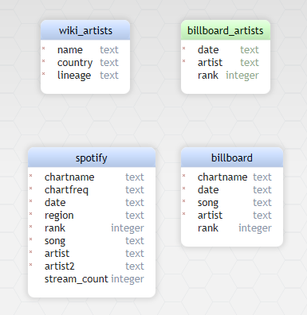

## Postprocessing

Different notebooks were used to create the files needed for the data visualization:

- df_bbg200_timeline.csv - contains the artists that ranked number 1 in the weekly Billboard Global 200 chart from September 2020 to July 2021, and whether they are Asian, mixed-Asian or non-Asian. Details of which can be found in 03B_EDA_timeline.ipynb
- counts_over_time.csv - contains the count of the top 100 Asians per month from December 2016 to July 2021 for Spotify Top 200 Global & US, Billboard Hot 100, and Billboard Global 200. Data processing steps can be viewed in 03C_EDA_ArtistsThroughTime.ipynb
- lineage_over_time.csv - provides the number of Asian and mixed-Asian who made it to Spotify Top 200 Global & US, Billboard Hot 100, and Billboard Global 200 from September 2020 to July 2021. Data processing steps can be viewed in 03C_EDA_ArtistsThroughTime.ipynb
- df_all_peaks.csv - contains the number of Asian and mixed-Asian artists who made it to the Spotify Top 200 Global & US, Billboard Hot 100, and Billboard Global 200 from September 2020 to July 2021. It also includes the artist's nationality, such as Filipino. Data processing steps can be viewed in 03D_EDA_peak_by_country.ipynb
- bubble_artist.csv and bubble_lineage.csv - contains subsets of the Spotify Top 200 weekly charts containing only entries from Asian artists where values were grouped by month and either by artist or by lineage. Data processing steps can be viewed in 03E_EDA_BubblePlots_AsianVMixed.ipynb

All csvs files were saved in the folder ./post_procesed_data and called in for their respective visualization.

# Exploratory Data Analysis

[figure not shown]

```python
def sql_spotify_chart(chartinfo):
    conn = sqlite3.connect('./pre_processed_data/lab2.db')
    my_sql = f"""
        SELECT lineage,
        COUNT(artist2)
        FROM spotify
        left join wiki_artists
        on name = artist2
        WHERE chartname = {chartinfo[0]} and
        chartfreq = {chartinfo[1]} and
        region = {chartinfo[2]} and
        date > '2016-12-29' and
        date < '2021-08-01'
        GROUP BY lineage
    """
    sptfy_dailyglobal_artist_df = (pd.read_sql(my_sql, conn)
                                   .replace([None], np.nan))
    conn.close()
    sptfy_dailyglobal_artist_df['lineage'].fillna('Non-Asian', inplace=True)
    sptfy_dailyglobal_artist_df.set_index('lineage', inplace=True)
    df_dict = sptfy_dailyglobal_artist_df.to_dict()
    df_dict = df_dict['COUNT(artist2)']
    total = sum(df_dict.values())
    answer = {k: (v/total)*100 for k,v in sorted(df_dict.items())}
    answer2 = [i for i in answer.values()]
    return answer2

spotify_top200_weekly_global = ('\'top200\'', '\'weekly\'', '\'global\'')
spotify_top200_weekly_us = ('\'top200\'', '\'weekly\'', '\'us\'')
spotify_viral50_weekly_global = ('\'viral50\'', '\'weekly\'', '\'global\'')
spotify_viral50_weekly_us = ('\'viral50\'', '\'weekly\'', '\'us\'')

spotify_data = (spotify_top200_weekly_global, spotify_top200_weekly_us,
                spotify_viral50_weekly_global, spotify_viral50_weekly_us)

spotify_titles = ['Spotify Top200 Weekly Global',
                  'Spotify Top200 Weekly US',
                  'Spotify Viral50 Weekly Global',
                  'Spotify Viral50 Weekly US']

top200_wk_global = sql_spotify_chart(spotify_top200_weekly_global)
top200_wk_us = sql_spotify_chart(spotify_top200_weekly_us)
viral50_wk_global = sql_spotify_chart(spotify_viral50_weekly_global)
viral50_wk_us = sql_spotify_chart(spotify_viral50_weekly_global)

data = pd.DataFrame(
{
    'lineage': ['Asian', 'Mixed-Asian', 'Non-Asian'],
    spotify_titles[0]: top200_wk_global,
    spotify_titles[1]: top200_wk_us,
    spotify_titles[2]: viral50_wk_global,
    spotify_titles[3]: viral50_wk_us
},
).set_index('lineage')

labels = [i for i in data.index]

fig = plt.figure(
FigureClass=Waffle,
plots={

221: {
'values': data[spotify_titles[0]],
'labels': labels,
'title': {'label': spotify_titles[0],'loc': 'center'},
'legend': {'loc': 'lower left', 'bbox_to_anchor': (.5, .1),
           'labels': [f"{k} ({v:.2f}%)" for
                      k, v in data[spotify_titles[0]].items()]}
},

222: {
'values': data[spotify_titles[1]],
'labels': labels,
'title': {'label': spotify_titles[1],'loc': 'center'},
'legend': {'loc': 'lower left', 'bbox_to_anchor': (.5, .1),
           'labels': [f"{k} ({v:.2f}%)" for
                      k, v in data[spotify_titles[1]].items()]}
},

223: {
'values': data[spotify_titles[2]],
'labels': labels,
'title': {'label': spotify_titles[2],'loc': 'center'},
'legend': {'loc': 'lower left', 'bbox_to_anchor': (.5, .1),
           'labels': [f"{k} ({v:.2f}%)" for
                      k, v in data[spotify_titles[2]].items()]}
},

224: {
'values': data[spotify_titles[3]],
'labels': labels,
'title': {'label': spotify_titles[3],'loc': 'center'},
'legend': {'loc': 'lower left', 'bbox_to_anchor': (.5, .1),
           'labels': [f"{k} ({v:.2f}%)" for
                      k, v in data[spotify_titles[3]].items()]}
}

},

starting_location='NW',
vertical=True,
rows=10,
columns=10,
rounding_rule='ceil',
colors=('#D9734E', '#F2B05E', '#D9D9D9'),
figsize=(8, 6),
)
plt.suptitle("Percentage of Asian and Mixed-Asians Artists on \
Spotify Charts", fontsize=15, ha='center', fontweight="bold")
pass
```

#### Figure 1. Percentage of Asian and Asian-American Artists in Spotify Charts

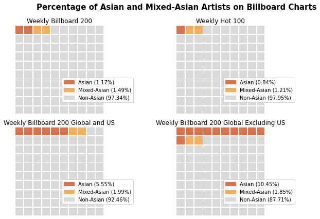

```python
def sql_billboard_charts(chartinfo):
    conn = sqlite3.connect('./pre_processed_data/lab2.db')
    my_sql = f"""
    SELECT *
    FROM billboard
    LEFT JOIN wiki_artists
    ON name = artist
    WHERE chartname = {chartinfo} and
    date > '2016-12-29' and
    date < '2021-08-01'
    """
    bb_artist_df = pd.read_sql(my_sql, conn).replace([None], np.nan)
    conn.close()

    bb_artist_df['country'].fillna('Non-Asian', inplace=True)
    bb_artist_df['lineage'].fillna('Non-Asian', inplace=True)
    bb_df = pd.DataFrame(bb_artist_df.groupby
                         ('lineage')['artist'].agg('count'))
    bb_df = bb_df.to_dict()
    bb_df = bb_df['artist']
    total = sum(bb_df.values())
    answer = {k: (v/total)*100 for k,v in sorted(bb_df.items())}
    answer2 = [i for i in answer.values()]
    return answer2

billboard_data = ['\'weekly_billboard_200\'',
                  '\'weekly_hot_100\'',
                  '\'weekly_billboard_global_200\'',
                  '\'weekly_billboard_global_exclUS_200\'']

billboard_titles = ['Weekly Billboard 200',
                    'Weekly Hot 100',
                    'Weekly Billboard 200 Global and US',
                    'Weekly Billboard 200 Global Excluding US']

wk_200 = sql_billboard_charts(billboard_data[0])
wk_hot100 = sql_billboard_charts(billboard_data[1])
wk_bb200_globalus = sql_billboard_charts(billboard_data[2])
wk_bb200_globalexus = sql_billboard_charts(billboard_data[3])

data = pd.DataFrame(
{
    'lineage': ['Asian', 'Mixed-Asian', 'Non-Asian'],
    billboard_titles[0]: wk_200,
    billboard_titles[1]: wk_hot100,
    billboard_titles[2]: wk_bb200_globalus,
    billboard_titles[3]: wk_bb200_globalexus
},
).set_index('lineage')

labels = [i for i in data.index]

fig = plt.figure(
FigureClass=Waffle,
plots={

221: {
'values': data[billboard_titles[0]],
'labels': labels,
'title': {'label': billboard_titles[0],'loc': 'center'},
'legend': {'loc': 'lower left', 'bbox_to_anchor': (.5, .1),
           'labels': [f"{k} ({v:.2f}%)" for
                      k, v in data[billboard_titles[0]].items()]}
},

222: {
'values': data[billboard_titles[1]],
'labels': labels,
'title': {'label': billboard_titles[1],'loc': 'center'},
'legend': {'loc': 'lower left', 'bbox_to_anchor': (.5, .1),
           'labels': [f"{k} ({v:.2f}%)" for
                      k, v in data[billboard_titles[1]].items()]}
},

223: {
'values': data[billboard_titles[2]],
'labels': labels,
'title': {'label': billboard_titles[2],'loc': 'center'},
'legend': {'loc': 'lower left', 'bbox_to_anchor': (.5, .1),
           'labels': [f"{k} ({v:.2f}%)" for
                      k, v in data[billboard_titles[2]].items()]}
},

224: {
'values': data[billboard_titles[3]],
'labels': labels,
'title': {'label': billboard_titles[3],'loc': 'center'},
'legend': {'loc': 'lower left', 'bbox_to_anchor': (.5, .1),
           'labels': [f"{k} ({v:.2f}%)" for
                      k, v in data[billboard_titles[3]].items()]}
}

},
starting_location='NW',
vertical=True,
rows=10,
columns=10,
rounding_rule='ceil',
colors=('#D9734E', '#F2B05E', '#D9D9D9'),
figsize=(9, 6),
)
plt.suptitle("Percentage of Asian and Mixed-Asian Artists on \
Billboard Charts", fontsize=15, ha='center', fontweight="bold")
pass
```

#### Figure 2. Percentage of Asian and Asian-American Artists on Billboard Charts

Figure 2 shows that both the Weekly Billboard 200 and the Weekly Hot 100 have a similar proportion of non-Asian artists dominating the charts appearing 97.34% to 97.95% of the time. However, in the Weekly Billboard 200 Global and US and Weekly Billboard 200 Global Excluding US charts, the Asian’s have a stronger presence at 5.55% and 10.45% respectively while mixed-Asians are present about 1.85% to 1.99% of the time. From the initial exploratory analysis, it can be seen the Asian musicians are most represented in Weekly Billboard 200 Global Excluding US charts which may be due to the exclusion of the US-centric metrics.

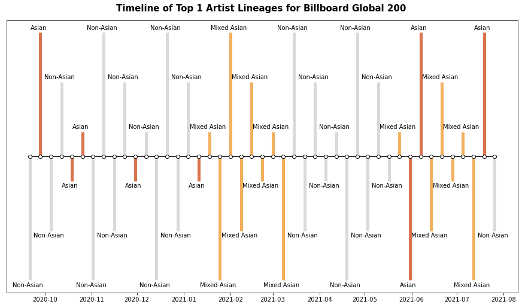

```python
# plot timeline for billboard global 200
df_tops = pd.read_csv('./post_processed_data/df_bbg200_timeline.csv')
df_tops['date'] = pd.to_datetime(df_tops['date'])
dates = df_tops['date'].to_list()
names = df_tops['lineage'].to_list()
colors = []
for n in names:
    if n == 'Asian':
        colors.append('#D9734E')
    elif n == 'Mixed Asian':
        colors.append('#F2B05E')
    else:
        colors.append('#D9D9D9')

levels = np.tile([-5, 5, -3, 3, -1, 1],
                 int(np.ceil(len(dates)/6)))[:len(dates)]

fig, ax = plt.subplots(figsize=(12, 7), constrained_layout=True)
fig.suptitle('Timeline of Top 1 Artist Lineages for Billboard Global 200',
             fontsize=15, fontweight="bold")
ax.vlines(dates, 0, levels, color=colors, linewidth=5)
ax.plot(dates, np.zeros_like(dates), "-o",
        color="k", markerfacecolor="w")

for d, l, r in zip(dates, levels, names):
    ax.annotate(r, xy=(d, l),
                xytext=(-3, np.sign(l)*3), textcoords="offset points",
                horizontalalignment="center",
                verticalalignment="bottom" if l > 0 else "top")

ax.yaxis.set_visible(False)
```

#### Figure 3. What are the lineages of the top 1 ranked artists for billboard global 200 chart?

Although the previous analysis shows that both Asians and mixed-Asians have a minimal presence in the Spotify and Billboard charts, a timeline showing the lineages of the top 1 ranked artists in Billboard Global 200 shows that Asians and mixed-Asians topped the charts almost half the time from September 21 2020 to July 26 2021. This visualization considers all the top 1 ranked artists per week during the specified period and tags their respective lineages, that is, whether they are Asian, mixed-Asians or non-Asian.

```python
df_charts_melt = pd.read_csv('./post_processed_data/counts_over_time.csv')

# range_ = ['#A67356', '#736766', '#1db954', '#191414']

chart_line = alt.Chart(df_charts_melt,
                       title="Asians in Different Charts through Time"
).mark_line().encode(
    x=alt.X('month_yr', axis=alt.Axis(title='Date')),
    y=alt.Y('value', scale=alt.Scale(domain=[0, 70]),
            axis=alt.Axis(title='Number of Time in Chart')),
    color=alt.Color('variable', legend=alt.Legend(title="Music Chart",
                                                  orient='top-left',
                                                  fillColor='white')),
    strokeDash='variable',
).properties(
    width=800,
    height=300
).configure_axis(
#     grid=False,
    labelFontSize=12,
    titleFontSize=15
).configure_title(
    fontSize=18,
    offset=5,
    orient='top',
    anchor='middle')

chart_line
```

[interactive chart not shown]

#### Figure 4. Have Asians/Mixed Asians performance been improving over time?

We have seen that Asians and mixed-Asians have very minimal presence in all music charts, but how exactly have they performed over the years? We aggregated by month the number of times an Asian or mixed-Asian entered the global and US weekly charts of Billboard and Spotify to find out. To be able to compare Billboard and Spotify, only the top 100 artists from each chart were obtained for this analysis.

We can see from Figure 4 that prior to 2020, Asians were not able to have 30 or more artists in any of the charts. However, there are still occasional peaks observed. From December 2016 to December 2019, Spotify Top 200 Weekly Global went above 20 twice: once in March 2017 and again in November 2018. The first in March 2017 was mostly due to Bruno Mars while the one in November 2018 was due to multiple appearances in the chart of Bruno Mars, Tyga, and Blackpink. Meanwhile, surprisingly, Spotify Top 200 Weekly US, had the highest count prior to 2020 which occurred on the April of 2019. This is still from multiple appearances of the same three artists: Bruno Mars, Tyga, and Blackpink but now with the addition of BTS. During the same month, in the Spotify Top 200 Weekly Global, Tyga was no longer in the charts.

Shifting to Billboard, the Billboard Hot 100 noticeably had less Asians and Mixed-Asians artists in their chart. In fact, there were months in Billboard Hot 100 with zero Asian or Mixed-Asians (January - February 2017, July - August 2019, and June 2020). This is somewhat expected given that Billboard Hot 100 is a more stringent chart that determines rank based on radio plays, streams and sales exclusively in the US compared to Spotify Top 200 charts which is determined by stream counts alone. This may mean that the radio plays and sales in the US can still be improved for Asians and mixed-Asians prior to 2020.

Moving away from pre-2020, by late 2020, a change in trend occurred across all charts. During this period, the peaks have more than doubled the size of the highest peak pre-2020. In addition to a change in trend, we can also observe the presence of a new chart: Billboard Global 200 which aims to capture streams and sales in various territories worldwide. What kind of artists influenced these sudden increases in 2020? We will be looking at the next charts to find out.

```python
df_orig_melt = pd.read_csv('./post_processed_data/lineage_over_time.csv')
stacked_bar = alt.Chart(df_orig_melt,
                        title="Asians and Mixed-Asians through time"
).mark_bar().encode(
    x=alt.X('month_yr:N', title=None),
    y=alt.Y('sum(value):Q', axis=alt.Axis(grid=False,
                                          title='Number of Time in Chart')),
    column=alt.Column('variable:N', title=None),
    color=alt.Color('lineage:N',
                    scale=alt.Scale(range=['#D9734E', '#F2B05E']))
).configure_view(
    strokeOpacity=0
).properties(
    width=180,
    height=300
).configure_axis(
    labelFontSize=12,
    titleFontSize=14
).configure_title(
    fontSize=18,
    offset=5,
    orient='top',
    anchor='middle')

stacked_bar
```

[interactive chart not shown]

#### Figure 5. Asians and Mixed-Asians through time

2020 to 2021 were an interesting time for Asians and mixed-Asians artists given how well they performed at this time.

As seen in Figure 5, in the late 2020 and early 2021, we can observe that Asians performed better than mixed-Asians in the global charts of both Billboard and Spotify. This can somehow be observed as well for Spotify Top 200 Weekly US but not to the same extent. Meanwhile, the Billboard Hot 100, was not able to capture this surge in Asian artists.

Second quarter of 2021 shifted the story wherein we now have mixed-Asians dominating all charts. Looking first at the two US charts, Billboard Hot 100 continued to have low counts of Asians but responded well to mixed-Asians. In the same manner, Spotify Top 200 Weekly US lost the high counts of Asians it had in late 2020, even having one month in 2021 with no Asians at all, yet was able to capture the rise in mixed-Asians. The two global charts also showed the increase of mixed-Asians but they were also able to retain a good number of Asian artists in their charts.

Another thing to note is that mixed-Asians entered Spotify charts a month earlier than the Billboard charts. In April 2021, Spotify already had double the counts for mixed-Asians of Billboard which only saw the increase in May. This can be explained by the fact that Billboard takes into account sales while Spotify only takes into account streams. Hence, we can say that the mixed-Asian artists first succeeded by gathering listeners through Spotify which later on translated to chart-topping sales.

```python
# Plot of Asians vs Mixed-Asians Countries through Time
df_all = pd.read_csv('./post_processed_data/df_all_peaks.csv')
stacked_bar = alt.Chart(df_all,
                        title="Asians and Mixed-Asians Countries Through Time"
).mark_bar().encode(
    x=alt.X('month:N', title=None),
    y=alt.Y('sum(count):Q', axis=alt.Axis(grid=False,
                                          title='Number of Time in Chart')),
    column=alt.Column('chartname:N', title=None),
    color=alt.Color('country:N',
                    scale=alt.Scale(range=['#ffc60a', '#005799', '#61baff',
                                           '#30916f', '#79d2a6', '#ff9a47',
                                           '#f06c00']

))
).configure_view(
    strokeOpacity=0
).properties(
    width=180,
    height=300
).configure_axis(
    labelFontSize=12,
    titleFontSize=14
).configure_title(
    fontSize=18,
    offset=5,
    orient='top',
    anchor='middle')

stacked_bar
```

[interactive chart not shown]

#### Figure 6. Who are the countries that contributed to the peak in 2020?

To further inspect the improvement in performance of Asians and mixed-Asians during 2020 and 2021, we drilled down to see which countries were the top contributors to this increase. The time period included was from September 2020 to July 2021, and only artists that made it to the top 100 of each chart were considered for this analysis. The darker colors represent artists that are pure Asians while their lighter counterparts represent artists that are mixed-Asians.

From this chart, we can see that the peak in mixed-Asian artists that occurred in the 2nd quarter of 2021 was largely due to artists that are Filipino American. This was shown for both Billboard and Spotify charts. During this period, Spotify charts were also able to capture another mixed-Asian nationality, which was Korean American, while this did not reflect in the Billboard charts.

Looking at the performance of Asian artists, we see that there is a steady contribution of South Korean artists to the chart toppers. The data also supports what many of us may have noticed in mainstream media, that among the Asian nationalities, South Korean artists were the highest contributors. For the global charts of Billboard and Spotify, we see there was a peak in South Korean artist appearances that occurred in the last quarter of 2020. Although they did not appear in the top charts as often after that period, they still maintained popularity and continued to be the largest Asian nationality represented in the charts.

It is also interesting to note that in the last quarter of 2020, there was a peak in Japanese artists appearing in the Billboard Global 200 charts. These Japanese artists comprised roughly half of the Asian representation during that period. This behavior was also captured in the Spotify Top 200 US chart, although not to the same extent. During this period, Japanese artists were the second most frequent Asian nationality to appear in the Billboard Global 200 and Spotify Top 200 US charts.

Considering all four charts, the top three most frequent Asian nationalities to appear were South Korean, Japanese and Filipino. For the Billboard charts, Filipino artists were included during the second quarter of 2021, while for Spotify charts, Filipino artists made it to the top 100 for majority of the months from September 2020 to July 2021.

```python
import pandas as pd
import numpy as np
import plotly.graph_objects as go
from plotly.subplots import make_subplots

df_monthly_lineage = pd.read_csv('./post_processed_data/bubble_lineage.csv')
df_artist_monthly = pd.read_csv('./post_processed_data/bubble_artist.csv')

color_dict = {'Chinese' : '#ffc60a',
              'Filipino' : '#005799',
              'Filipino American' : '#61baff',
              'Japanese' : '#30916f',
              'Japanese American' : '#79d2a6',
              'Korean American' : '#ff9a47',
              'South Korean' : '#f06c00'}
lineage_color_dict = {'Asian':'#D9734E',
                      'Mixed Asian' : '#F2B05E'}

fig = make_subplots(rows=2,
                    shared_xaxes=True,
                    vertical_spacing = 0.0125,
                    row_heights = [1,5])

# Bar Plot at Row 1
for lineage in df_monthly_lineage.lineage.unique():
    bar_df = df_monthly_lineage[df_monthly_lineage.lineage == lineage]
    fig.add_trace(go.Bar(
            x= bar_df.date,
            y= bar_df.stream_count,
            name = lineage,
            marker_color = lineage_color_dict[lineage]
        ),
    row = 1,
    col = 1
    )


for country in df_artist_monthly.country.unique():
    sub = df_artist_monthly[df_artist_monthly.country == country]
    fig.add_trace(
        go.Scatter(x = sub.date,
                   y = sub.artist2,
                   mode = 'markers',
                   legendgroup = '1',
                   name = country,
                   marker = dict(
                           size = sub.stream_count,
                           sizemode = 'area',
                           sizeref = 2*max(df_artist_monthly.stream_count)/(40**2),
                           sizemin = 1,
                           color = sub.color
                   )
                  ),
        row = 2,
        col = 1
    )


fig.add_annotation(text="Asians overtake<br>Mixed Asians<br>"
                   "in total<br>Spotify Streams",
                    xref="x1", yref="paper",
                    x='2018-05-30', y=1,
                    font = dict(size = 10),
                    showarrow=False)

fig.add_annotation(text="Olivia Rodrigo<br>releases<br>drivers license",
                    xref="x1", yref="paper",
                    x='2021-01-31', y=1,
                    font = dict(size = 10),
                    showarrow=False)

fig.add_annotation(text="Global Korean Pop Craze",
                    xref="paper", yref="paper",
                    x=0.55, y=1.025,
                    font = dict(size = 10),
                    showarrow=False)

fig.update_layout(
    width=1000,
    height=1150,
    xaxis2_title="<b>Dates<b>",
    yaxis1_title="<b>Total # of Streams<b>",
    yaxis2_title="<b>Artists<b>",
    title={
        'text': "<b>Total # of Streamers per Month of Asian Artists<b>",
        'y':0.975,
        'x':0.5,
        'xanchor': 'center',
        'yanchor': 'top'},
    legend_title="Artist Classification",
    hovermode=False,
    legend_traceorder = "reversed+grouped",
    template='none',
    shapes = [
        dict(type = 'rect',
            x0= '0.02',
            y0= '0.565',
            x1= '0.0125',
            y1= '0.8',
            xref = 'paper',
            yref = 'paper',
            opacity = 1,
            fillcolor = '#F2B05E',
            line_width=0,
            ),
        dict(type = 'rect',
            x0= '0.02',
            y0= '0',
            x1= '0.0125',
            y1= '0.565',
            xref = 'paper',
            yref = 'paper',
            opacity = 1,
            fillcolor = '#D9734E',
            line_width=0,
            ),
        dict(type = 'line',
            x0= '2018-05-30',
            y0= '0',
            x1= '2018-05-30',
            y1= '1',
            xref = 'x1',
            yref = 'paper',
            opacity = 0.25,
            line = dict(dash= "dot")
            ),
        dict(type = 'line',
            x0= '2021-01-31',
            y0= '0',
            x1= '2021-01-31',
            y1= '1',
            xref = 'x1',
            yref = 'paper',
            opacity = 0.25,
            line = dict(dash= "dot")
            ),
        dict(type = 'rect',
            x0= '2018-05-30',
            y0= '0',
            x1= '2021-01-31',
            y1= '1',
            xref = 'x1',
            yref = 'paper',
            opacity = 0.1,
            fillcolor = '#C79BF2',
            layer="below",
            line_width=0,
            )
    ]
)

fig.update_yaxes(
    ticklabelposition="outside",
    automargin = True,
    title_standoff = 25
)
fig.show()
```

[interactive chart not shown]

#### Figure 7. Asian and Asian-American Artist Streams through Time

Our findings show that although Asian American musicians such as Bruno Mars and Hailee Steinfield dominated Spotify's Top 200 Weekly Global Charts from 2017 to the first quarter of 2018, an evident breakthrough by purely Asian descent musicians/groups was seen in May 2018 where the likes of Vietnamese singer, Tyga, and Korean Groups, BTS and Blackpink had overtaken Asian-American musicians in terms of total Spotify streams. Evidently, the release of hit songs and albums such as “Map of the Soul”, “How You Like That”, and “Dynamite” from BTS and Blackpink had a huge bearing in the performance of Asian musicians. However, a significant contribution from British-based Filipino artist, Beabadoobee - particularly through her song “Death Bed”, can also be noticed during the 2nd to 3rd quarter of 2020.

# Conclusion

We were interested to find out if Asians of both mixed and pure lineage were experiencing increased representation in the music industry. Our data shows that although they are still a minority compared to non-Asian musicians, there has been an increasing trend in their appearance in top charts and streams by the general public. Currently, Asian representation is largely due to mixed-Asian artists such as Olivia Rodrigo, but there has also been a notable increase in appearances of pure Asian artists in the top charts. This is largely due to South Korean artists such as BTS and Blackpink, but with notable contributions by pure Japanese artists like Yoko Ono and Joji, along with pure Filipino artists such as Beabadoobee.

Asians can take heart in the realization that there are concrete improvements in their goal of becoming an integral part of the music culture not only in Asia but more notably in the US, Europe and other continents as well.

# Recommendation

Our study looked mostly at music to see how Asians have become integrated in mainstream music culture. We don’t have to stop here. We can continue to look at other platforms as well as other aspects of culture to see whether Asians have made strides in these other areas as well. Spotify only recently launched in Korea because they had an alternative music streaming platform. We can further look at the data of the Korean music streaming app called Melon. Using this data, maybe we can find other insights of Asian integration into western culture. An interesting extension to this study would be to look at other aspects of culture such as movie, TV shows and determine how Asians have become part of western culture for these cultural aspects.

Korean artists have made the biggest inroads into western musical culture. An investigation using Google reveals that the probable reason for this success in penetrating the westerm musical culture (aside from the rise of social media platforms) is probably due to the huge investment that the Korean government made in providing financial and political resources for their artists.

Other countries who want to share their culture with the world could stand to follow in the footsteps of the Korean government’s efforts.

# Acknowledgement and References

https://radar.promogogo.com/announcement/understanding-spotifys-viral-charts/4c3b7b32

https://blog.chartmetric.com/chart-summaries-boiling-music-charts-down-to-their-dna/

https://radar.promogogo.com/announcement/How-Spotifys-Viral-Charts-Work/e48c837ddbab4875